# Introduction to advanced dimensionality reduction

Mburu

4/8/2020

## Exploring MNIST dataset

You will use the MNIST dataset in several exercises through the course. Let’s do some data exploration to gain a better understanding. Remember that the MNIST dataset contains a set of records that represent handwritten digits using 28x28 features, which are stored into a 784-dimensional vector.

mnistInput

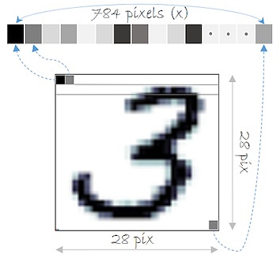

Each record of the MNIST dataset corresponds to a handwritten digit and each feature represents one pixel of the digit image. In this exercise, a sample of 200 records of the MNIST dataset named mnist_sample is loaded for you.

```r
load("mnist-sample-200.RData")
# Have a look at the MNIST dataset names
#names(mnist_sample)

# Show the first records
#str(mnist_sample)

# Labels of the first 6 digits
head(mnist_sample$label)
```

```
## [1] 5 0 7 0 9 3
```

## Digits features

Let’s continue exploring the dataset. Firstly, it would be helpful to know how many different digits are present by computing a histogram of the labels. Next, the basic statistics (min, mean, median, maximum) of the features for all digits can be calculated. Finally, you will compute the basic statistics for only those digits with label 0. The MNIST sample data is loaded for you as mnist_sample.

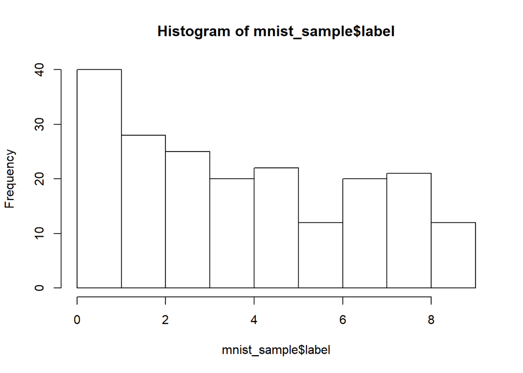

```r
# Plot the histogram of the digit labels
hist(mnist_sample$label)
```

```r
# Compute the basic statistics of all records
#summary(mnist_sample)

# Compute the basic statistics of digits with label 0
#summary(mnist_sample[, mnist_sample$label == 0])
```

## Euclidean distance

Euclidean distance is the basis of many measures of similarity and is the most important distance metric. You can compute the Euclidean distance in R using the dist() function. In this exercise, you will compute the Euclidean distance between the first 10 records of the MNIST sample data.

The mnist_sample object is loaded for you.

```r
# Show the labels of the first 10 records
mnist_sample$label[1:10]
```

```
##  [1] 5 0 7 0 9 3 4 1 2 6
```

```r
# Compute the Euclidean distance of the first 10 records
distances <- dist(mnist_sample[1:10, -1])

# Show the distances values
distances
```

```
##           1        2        3        4        5        6        7        8
## 2  2185.551
## 3  2656.407 2869.979
## 4  2547.027 2341.249 2936.772
## 5  2406.509 2959.108 1976.406 2870.928
## 6  2343.982 2759.681 2452.568 2739.470 2125.723
## 7  2464.388 2784.158 2573.667 2870.918 2174.322 2653.703
## 8  2149.872 2668.903 1999.892 2585.980 2067.044 2273.248 2407.962
## 9  2959.129 3209.677 2935.262 3413.821 2870.746 3114.508 2980.663 2833.447
## 10 2728.657 3009.771 2574.752 2832.521 2395.589 2655.864 2464.301 2550.126
##           9
## 2
## 3
## 4
## 5
## 6
## 7
## 8
## 9
## 10 2695.166
```

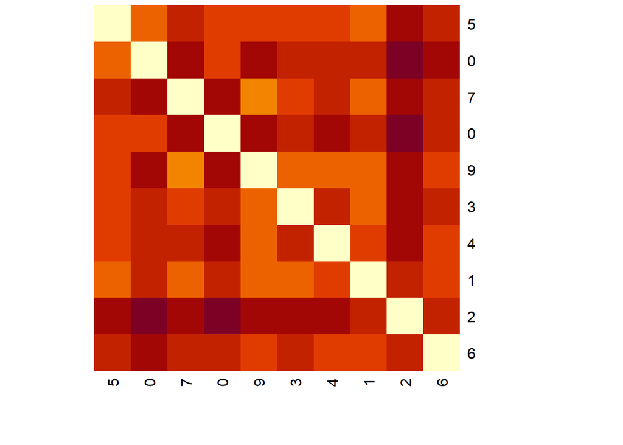

```r
# Plot the numeric matrix of the distances in a heatmap
heatmap(as.matrix(distances),
        Rowv = NA, symm = TRUE,
        labRow = mnist_sample$label[1:10],
        labCol = mnist_sample$label[1:10])
```

## Minkowsky distance

There are other well-known distance metrics besides the Euclidean distance, like the Minkowski distance. This metric can be considered a generalisation of both the Euclidean and Manhattan distance. In R, you can calculate the Minkowsky distance of order p by using dist(…, method = “minkowski”, p).

The MNIST sample data is loaded for you as mnist_sample

```r
# Minkowski distance or order 3
distances_3 <- dist(mnist_sample[1:10, -1], method = "minkowski", p = 3)

distances_3
```

```
##            1         2         3         4         5         6         7
## 2  1002.6468
## 3  1169.6470 1228.8295
## 4  1127.4919 1044.9182 1249.6133
## 5  1091.3114 1260.3549  941.1654 1231.7432
## 6  1063.7026 1194.1212 1104.2581 1189.9558  996.2687
## 7  1098.4279 1198.8891 1131.4498 1227.7888 1005.7588 1165.4475
## 8  1006.9070 1169.4720  950.6812 1143.3503  980.6450 1056.1814 1083.2255
## 9  1270.0240 1337.2068 1257.4052 1401.2461 1248.0777 1319.2768 1271.7095
## 10 1186.9620 1268.1539 1134.0371 1219.1388 1084.5416 1166.9129 1096.3586
##            8         9
## 2
## 3
## 4
## 5
## 6
## 7
## 8
## 9  1236.9178
## 10 1133.2929 1180.7970
```

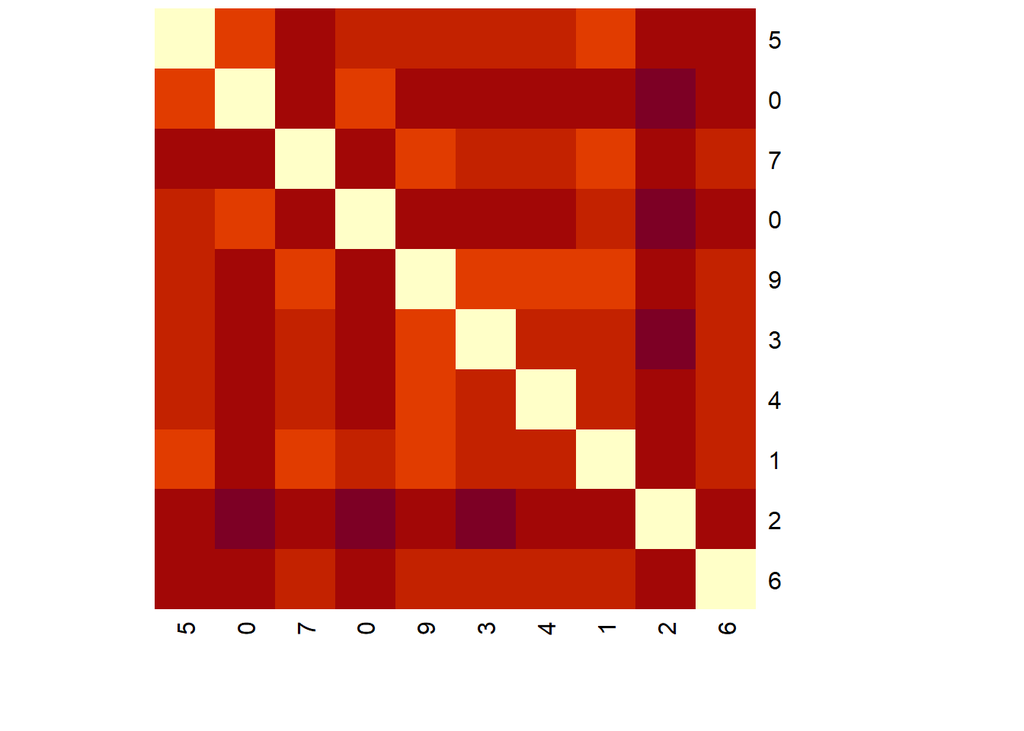

```r
heatmap(as.matrix(distances_3 ),
        Rowv = NA, symm = TRUE,
        labRow = mnist_sample$label[1:10],
        labCol = mnist_sample$label[1:10])
```

```r
# Minkowski distance of order 2
distances_2 <- dist(mnist_sample[1:10, -1], method = "minkowski", p = 2)
distances_2
```

```
##           1        2        3        4        5        6        7        8
## 2  2185.551
## 3  2656.407 2869.979
## 4  2547.027 2341.249 2936.772
## 5  2406.509 2959.108 1976.406 2870.928
## 6  2343.982 2759.681 2452.568 2739.470 2125.723
## 7  2464.388 2784.158 2573.667 2870.918 2174.322 2653.703
## 8  2149.872 2668.903 1999.892 2585.980 2067.044 2273.248 2407.962
## 9  2959.129 3209.677 2935.262 3413.821 2870.746 3114.508 2980.663 2833.447
## 10 2728.657 3009.771 2574.752 2832.521 2395.589 2655.864 2464.301 2550.126
##           9
## 2
## 3
## 4
## 5
## 6
## 7
## 8
## 9
## 10 2695.166
```

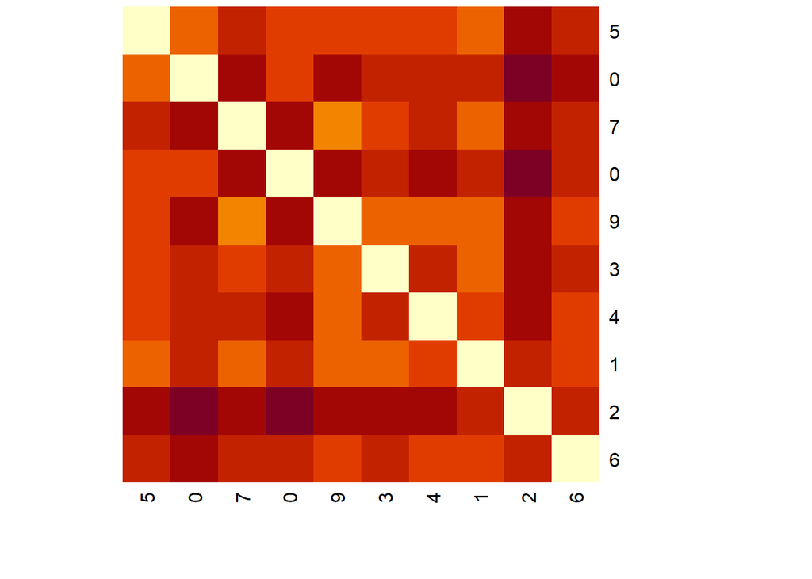

```r
heatmap(as.matrix(distances_2),
        Rowv = NA, symm = TRUE,
        labRow = mnist_sample$label[1:10],
        labCol = mnist_sample$label[1:10])
```

- Very Good! As you can see, when using Minkowski distance of order 2 the most similar digits are in positions 3 and 5 of the heatmap grid which corresponds to digits 7 and 9.

## KL divergence

There are more distance metrics that can be used to compute how similar two feature vectors are. For instance, the philentropy package has the function distance(), which implements 46 different distance metrics. For more information, use ?distance in the console. In this exercise, you will compute the KL divergence and check if the results differ from the previous metrics. Since the KL divergence is a measure of the difference between probability distributions you need to rescale the input data by dividing each input feature by the total pixel intensities of that digit. The philentropy package and mnist_sample data have been loaded.

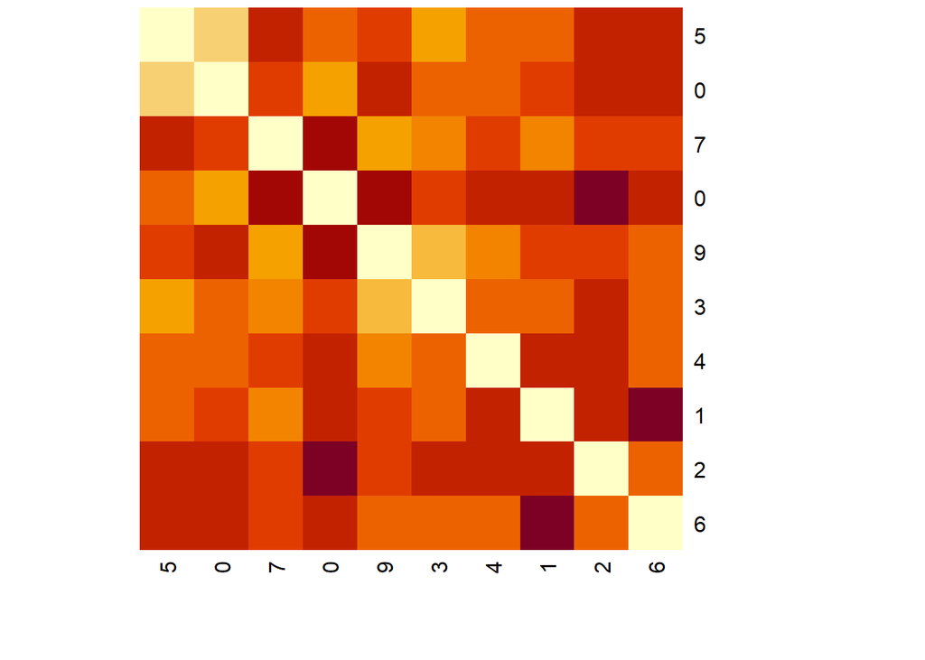

```r
library(philentropy)
library(tidyverse)
# Get the first 10 records
mnist_10 <- mnist_sample[1:10, -1]

# Add 1 to avoid NaN when rescaling
mnist_10_prep <- mnist_10 + 1

# Compute the sums per row
sums <- rowSums(mnist_10_prep)

# Compute KL divergence
distances <- distance(mnist_10_prep/sums, method = "kullback-leibler")
heatmap(as.matrix(distances),
        Rowv = NA, symm = TRUE,
        labRow = mnist_sample$label[1:10],
        labCol = mnist_sample$label[1:10])
```

## Generating PCA from MNIST sample

You are going to compute a PCA with the previous mnist_sample dataset. The goal is to have a good representation of each digit in a lower dimensional space. PCA will give you a set of variables, named principal components, that are a linear combination of the input variables. These principal components are ordered in terms of the variance they capture from the original data. So, if you plot the first two principal components you can see the digits in a 2-dimensional space. A sample of 200 records of the MNIST dataset named mnist_sample is loaded for you.

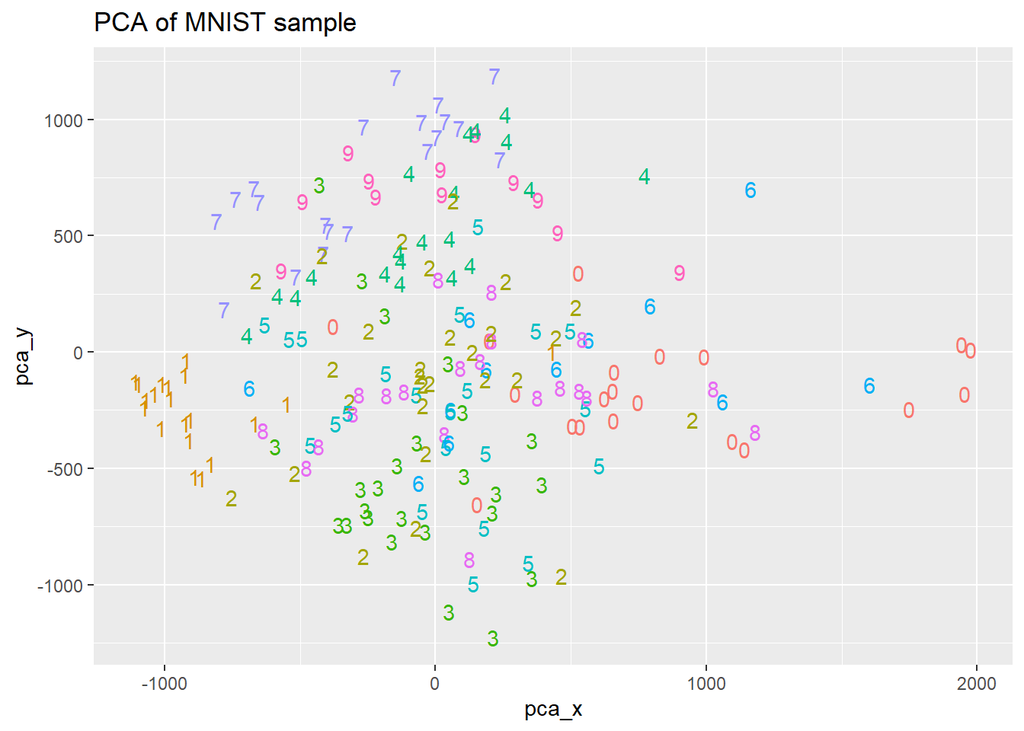

```r
# Get the principal components from PCA
pca_output <- prcomp(mnist_sample[, -1])

# Observe a summary of the output
#summary(pca_output)

# Store the first two coordinates and the label in a data frame
pca_plot <- data.frame(pca_x = pca_output$x[, "PC1"], pca_y = pca_output$x[, "PC2"],
                       label = as.factor(mnist_sample$label))

# Plot the first two principal components using the true labels as color and shape
ggplot(pca_plot, aes(x = pca_x, y = pca_y, color = label)) +
    ggtitle("PCA of MNIST sample") +
    geom_text(aes(label = label)) +
    theme(legend.position = "none")
```

## t-SNE output from MNIST sample

You have seen that PCA has some limitations in correctly classifying digits, mainly due to its linear nature. In this exercise, you are going to use the output from the t-SNE algorithm on the MNIST sample data, named tsne_output and visualize the obtained results. In the next chapter, you will focus on the t-SNE algorithm and learn more about how to use it! The MNIST sample dataset mnist_sample as well as the tsne_output are available in your workspace.

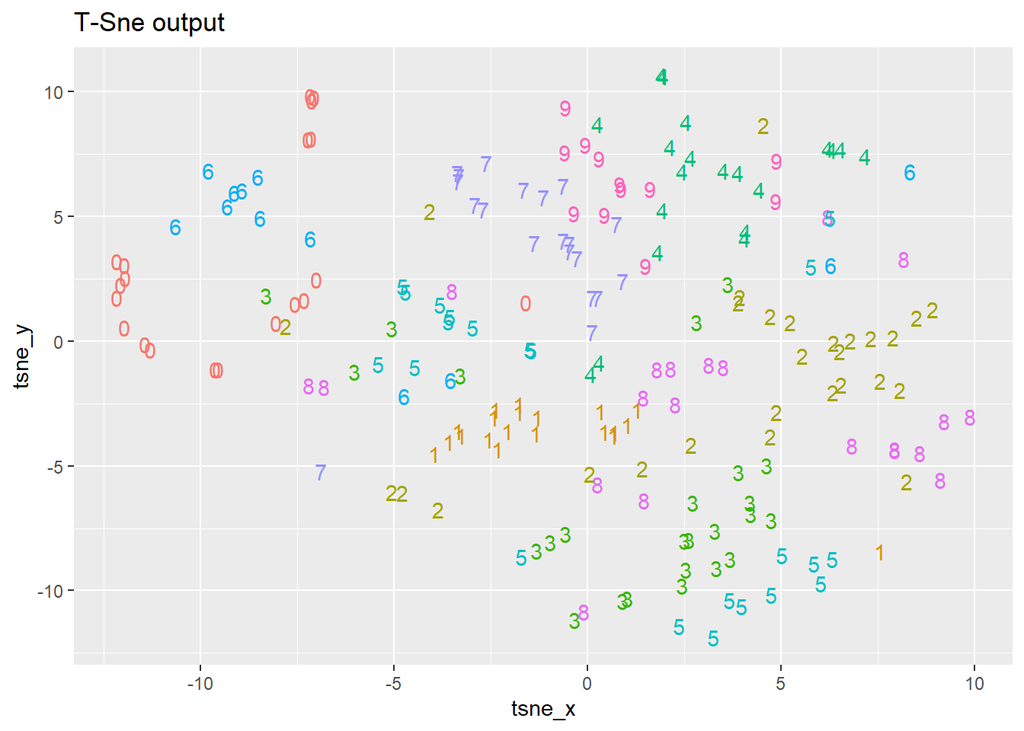

```r
# Explore the tsne_output structure
library(Rtsne)
library(tidyverse)
tsne_output <- Rtsne(mnist_sample[, -1])
#str(tsne_output)

# Have a look at the first records from the t-SNE output
#head(tsne_output)

# Store the first two coordinates and the label in a data.frame
tsne_plot <- data.frame(tsne_x = tsne_output$Y[, 1], tsne_y = tsne_output$Y[, 2],
                        label = as.factor(mnist_sample$label))

# Plot the t-SNE embedding using the true labels as color and shape
ggplot(tsne_plot, aes(x =tsne_x, y = tsne_y, color = label)) +
    ggtitle("T-Sne output") +
    geom_text(aes(label = label)) +
    theme(legend.position = "none")
```

## Computing t-SNE

As we have seen, the t-SNE embedding can be computed in R using the Rtsne() function from the Rtsne package in CRAN. Performing a PCA is a common step before running the t-SNE algorithm, but we can skip this step by setting the parameter PCA to FALSE. The dimensionality of the embedding generated by t-SNE can be indicated with the dims parameter. In this exercise, we will generate a three-dimensional embedding from the mnist_sample dataset without doing the PCA step and then, we will plot the first two dimensions. The MNIST sample dataset mnist_sample, as well as the Rtsne and ggplot2 packages, are already loaded.

```r
# Compute t-SNE without doing the PCA step
tsne_output <- Rtsne(mnist_sample[,-1], PCA = FALSE, dim = 3)

# Show the obtained embedding coordinates
head(tsne_output$Y)
```

```
##             [,1]       [,2]       [,3]
## [1,]  -7.3346340 -3.2988969   6.637910
## [2,] -13.4635381 -4.4324708   3.483948
## [3,]   3.2567616  0.0358222   7.449515
## [4,]  -6.6996874 -8.1490533 -13.881727
## [5,]   5.5569390  0.5837852   4.626039
## [6,]   0.1211008 -8.4427165   8.175474
```

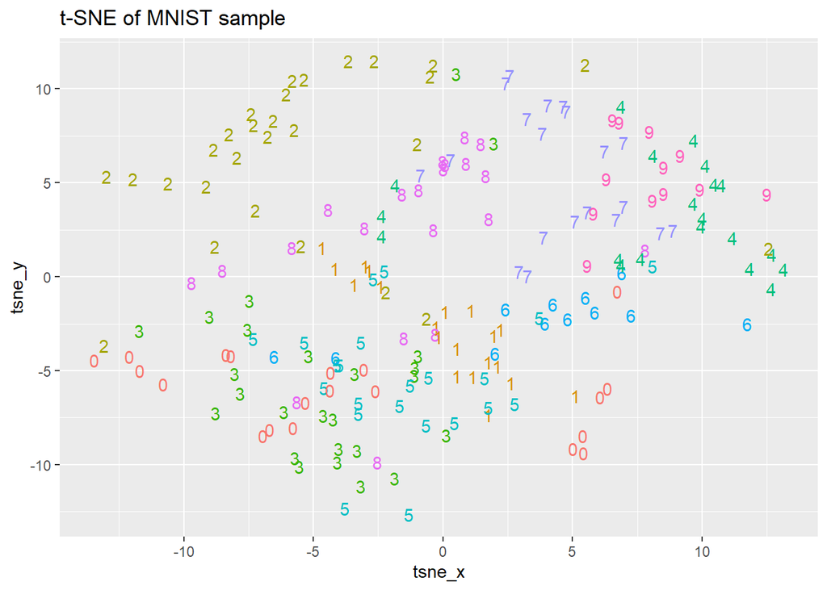

```r
# Store the first two coordinates and plot them
tsne_plot <- data.frame(tsne_x = tsne_output$Y[, 1], tsne_y = tsne_output$Y[, 2],
                        digit = as.factor(mnist_sample$label))

# Plot the coordinates
ggplot(tsne_plot, aes(x = tsne_x, y = tsne_y, color = digit)) +
    ggtitle("t-SNE of MNIST sample") +
    geom_text(aes(label = digit)) +
    theme(legend.position = "none")
```

## Understanding t-SNE output

The most important t-SNE output are those related to the K-L divergence of the points in the original high dimensions and in the new lower dimensional space. Remember that the goal of t-SNE is to minimize the K-L divergence between the original space and the new one. In the returned object, the itercosts structure indicates the total cost from the K-L divergence of all the objects in each 50th iteration and the cost structure indicates the K-L divergence of each record in the final iteration. The Rtsne package and the tsne_output object have been loaded for you.

```r
# Inspect the output object's structure
str(tsne_output)
```

```
## List of 14
##  $ N                  : int 200
##  $ Y                  : num [1:200, 1:3] -7.33 -13.46 3.26 -6.7 5.56 ...
##  $ costs              : num [1:200] 0.003888 0.003392 0.000083 0.002981 0.001542 ...
##  $ itercosts          : num [1:20] 54.1 54.4 54.3 52.6 53.3 ...
##  $ origD              : int 50
##  $ perplexity         : num 30
##  $ theta              : num 0.5
##  $ max_iter           : num 1000
##  $ stop_lying_iter    : int 250
##  $ mom_switch_iter    : int 250
##  $ momentum           : num 0.5
##  $ final_momentum     : num 0.8
##  $ eta                : num 200
##  $ exaggeration_factor: num 12
```

```r
# Show total costs after each 50th iteration
tsne_output$itercosts
```

```
##  [1] 54.0581796 54.3708333 54.3107925 52.6299027 53.3211051  1.0781999
##  [7]  0.6096221  0.5443157  0.5333645  0.5280972  0.5264523  0.5237639
## [13]  0.5249121  0.5235953  0.5205295  0.5181666  0.5131187  0.5110753
## [19]  0.5099081  0.5076532
```

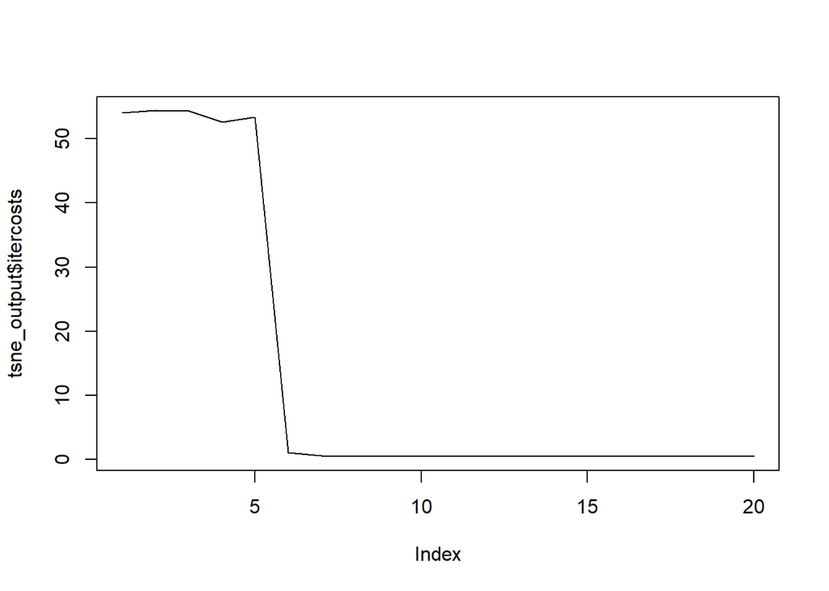

```r
# Plot the evolution of the KL divergence at each 50th iteration
plot(tsne_output$itercosts, type = "l")
```

```r
# Inspect the output object's structure
str(tsne_output)
```

```
## List of 14
##  $ N                  : int 200
##  $ Y                  : num [1:200, 1:3] -7.33 -13.46 3.26 -6.7 5.56 ...
##  $ costs              : num [1:200] 0.003888 0.003392 0.000083 0.002981 0.001542 ...
##  $ itercosts          : num [1:20] 54.1 54.4 54.3 52.6 53.3 ...
##  $ origD              : int 50
##  $ perplexity         : num 30
##  $ theta              : num 0.5
##  $ max_iter           : num 1000
##  $ stop_lying_iter    : int 250
##  $ mom_switch_iter    : int 250
##  $ momentum           : num 0.5
##  $ final_momentum     : num 0.8
##  $ eta                : num 200
##  $ exaggeration_factor: num 12
```

```r
# Show the K-L divergence of each record after the final iteration
tsne_output$costs
```

```
##   [1]  3.888468e-03  3.391758e-03  8.303738e-05  2.981037e-03  1.541937e-03
##   [6]  3.806237e-03  2.754610e-03  1.020680e-03  1.910185e-03  1.748042e-03
##  [11]  2.359723e-03  2.362194e-03  2.305383e-03  1.260216e-03  4.001393e-03
##  [16]  2.397943e-03  3.635695e-03  2.812471e-03  1.221100e-03  2.538986e-03
##  [21]  1.473445e-03  1.480181e-03  2.530629e-03  1.882970e-03  3.363067e-03
##  [26]  2.630319e-03  1.414363e-03  3.309381e-03  5.091969e-03  1.100554e-03
##  [31]  5.784850e-03  2.439103e-03  6.081287e-03  1.983660e-03  2.943058e-03
##  [36]  3.738755e-03  4.760790e-03  3.104789e-03  6.112094e-04  3.935229e-03
##  [41]  4.709756e-03  2.855708e-03  2.015058e-03  1.682894e-03  3.581559e-03
##  [46]  2.739139e-03  2.433006e-03  5.174491e-03  6.707085e-04  4.693154e-03
##  [51]  2.473905e-03  5.991886e-03  1.462249e-03  5.199388e-03  3.101052e-03
##  [56]  6.918877e-03  1.405320e-03  3.184016e-03  1.929555e-05  1.435464e-03
##  [61]  2.969567e-03  1.113110e-03  6.549423e-04  1.681457e-03  3.022101e-03
##  [66]  1.561930e-03  8.793697e-04  1.071068e-03  1.349304e-03  1.508129e-03
##  [71]  2.689855e-03  4.274962e-03  9.620761e-04  2.790520e-03  7.826684e-04
```

[output cut: 25 more lines]

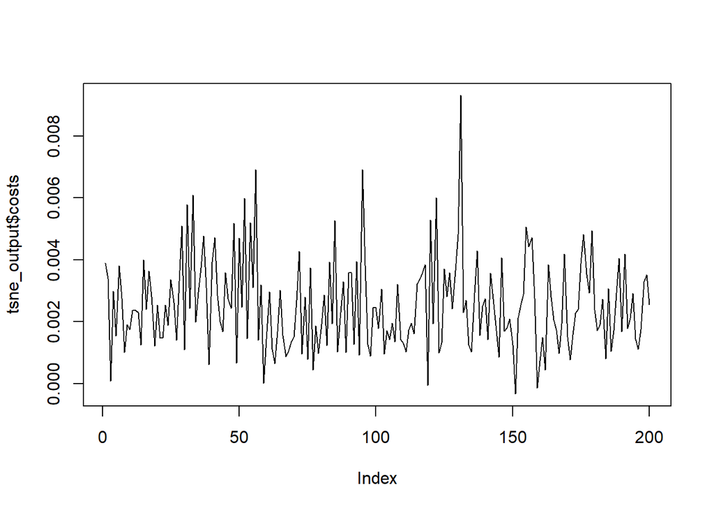

```r
# Plot the K-L divergence of each record after the final iteration
plot(tsne_output$costs, type = "l")
```

## Reproducing results

t-SNE is a stochastic algorithm, meaning there is some randomness inherent to the process. To ensure reproducible results it is necessary to fix a seed before every new execution. This way, you can tune the algorithm hyper-parameters and isolate the effect of the randomness. In this exercise, the goal is to generate two embeddings and check that they are identical. The mnist_sample dataset is available in your workspace.

```r
# Generate a three-dimensional t-SNE embedding without PCA
tsne_output <- Rtsne(mnist_sample[, -1], PCA = FALSE, dim = 3)

# Generate a new t-SNE embedding with the same hyper-parameter values
tsne_output_new <- Rtsne(mnist_sample[, -1], PCA = FALSE, dim = 3)

# Check if the two outputs are identical
identical(tsne_output, tsne_output_new)
```

```
## [1] FALSE
```

```r
# Generate a three-dimensional t-SNE embedding without PCA
set.seed(1234)
tsne_output <- Rtsne(mnist_sample[, -1], PCA = FALSE, dims = 3)

# Generate a new t-SNE embedding with the same hyper-parameter values
set.seed(1234)
tsne_output_new <- Rtsne(mnist_sample[, -1], PCA = FALSE, dims = 3)

# Check if the two outputs are identical
identical(tsne_output, tsne_output_new)
```

```
## [1] TRUE
```

## Optimal number of iterations

A common hyper-parameter to optimize in t-SNE is the optimal number of iterations. As you have seen before it is important to always use the same seed before you can compare different executions. To optimize the number of iterations, you can increase the max_iter parameter of Rtsne() and observe the returned itercosts to find the minimum K-L divergence. The mnist_sample dataset and the Rtsne package have been loaded for you.

```r
# Set seed to ensure reproducible results
set.seed(1234)

# Execute a t-SNE with 2000 iterations
tsne_output <- Rtsne(mnist_sample[, -1], max_iter = 2000,PCA = TRUE, dims = 2)

# Observe the output costs
tsne_output$itercosts
```

```
##  [1] 53.2961580 52.7595763 52.9243318 53.8975509 54.7866761  1.0907342
##  [7]  0.8668795  0.7939365  0.7715459  0.7389568  0.7034065  0.6829576
## [13]  0.6743824  0.6518515  0.6480134  0.6477325  0.6462515  0.6463141
## [19]  0.6497671  0.6492903  0.6500593  0.6502865  0.6503155  0.6505163
## [25]  0.6514624  0.6505526  0.6508033  0.6533249  0.6503375  0.6488921
## [31]  0.6504220  0.6475876  0.6502446  0.6494466  0.6461031  0.6398683
## [37]  0.6369844  0.6387022  0.6398072  0.6383595
```

```r
# Get the 50th iteration with the minimum K-L cost
which.min(tsne_output$itercosts)
```

```
## [1] 37
```

## Perplexity of MNIST sample

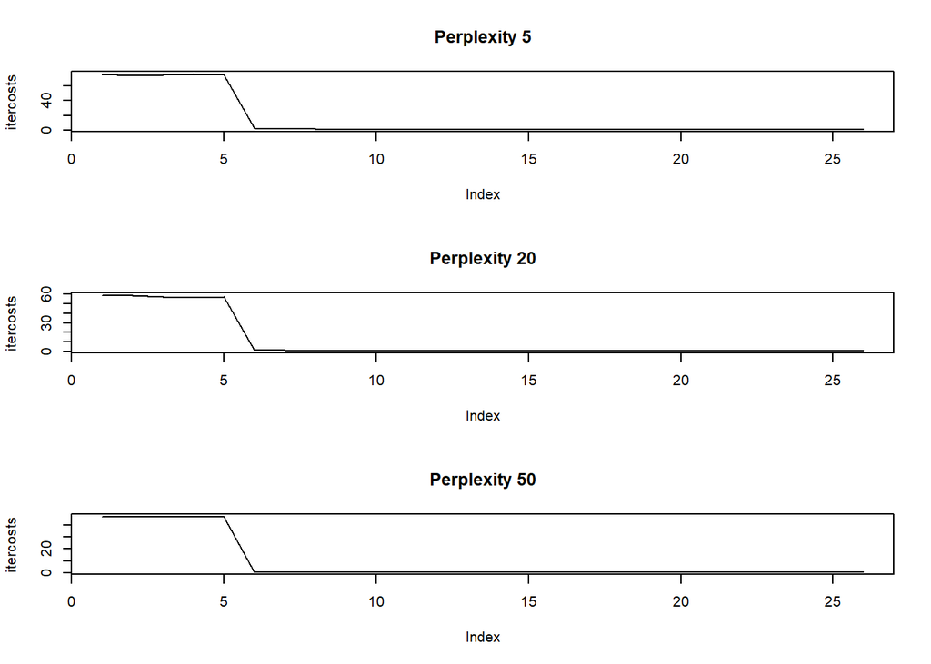

```r
# Set seed to ensure reproducible results
par(mfrow = c(3, 1))
set.seed(1234)

perp <- c(5, 20, 50)
models <- list()
for (i in 1:length(perp)) {

        # Execute a t-SNE with perplexity 5
        perplexity  = perp[i]
        tsne_output <- Rtsne(mnist_sample[, -1], perplexity = perplexity, max_iter = 1300)
        # Observe the returned K-L divergence costs at every 50th iteration
        models[[i]] <- tsne_output
        plot(tsne_output$itercosts,
             main = paste("Perplexity", perplexity),
             type = "l", ylab = "itercosts")
}
```

```r
names(models) <- paste0("perplexity",perp)
```

## Perplexity of bigger MNIST dataset

Now, let’s investigate the effect of the perplexity values with a bigger MNIST dataset of 10.000 records. It would take a lot of time to execute t-SNE for this many records on the DataCamp platform. This is why the pre-loaded output of two t-SNE embeddings with perplexity values of 5 and 50, named tsne_output_5 and tsne_output_50 are available in the workspace. We will look at the K-L costs and plot them using the digit label from the mnist_10k dataset, which is also available in the environment. The Rtsne and ggplot2 packages have been loaded.

- I used mnist smaller data set

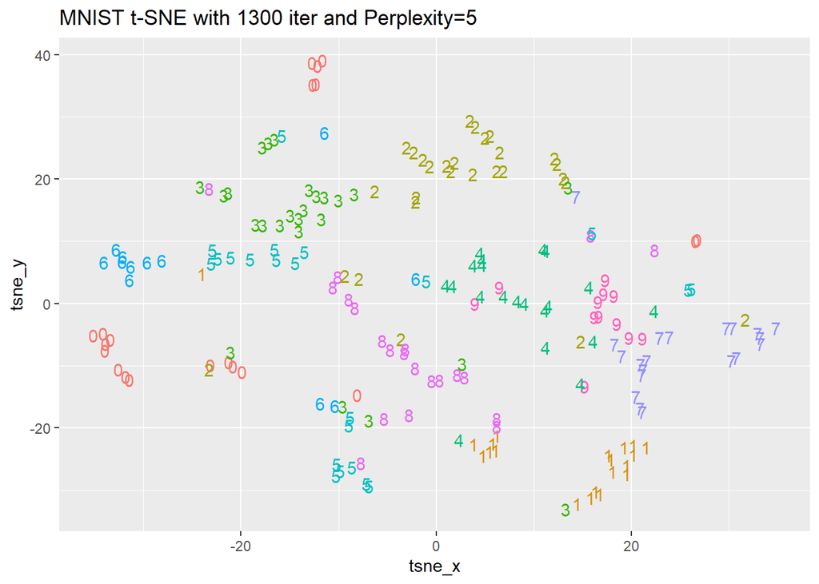

```r
# Observe the K-L divergence costs with perplexity 5 and 50
tsne_output_5 <- models$perplexity5
tsne_output_50  <- models$perplexity50
# Generate the data frame to visualize the embedding
tsne_plot_5 <- data.frame(tsne_x = tsne_output_5$Y[, 1], tsne_y = tsne_output_5$Y[, 2], digit = as.factor(mnist_sample$label))

tsne_plot_50 <- data.frame(tsne_x = tsne_output_50$Y[, 1], tsne_y = tsne_output_50$Y[, 2], digit = as.factor(mnist_sample$label))

# Plot the obtained embeddings
ggplot(tsne_plot_5, aes(x = tsne_x, y = tsne_y, color = digit)) +
    ggtitle("MNIST t-SNE with 1300 iter and Perplexity=5") +
    geom_text(aes(label = digit)) +
    theme(legend.position="none")
```

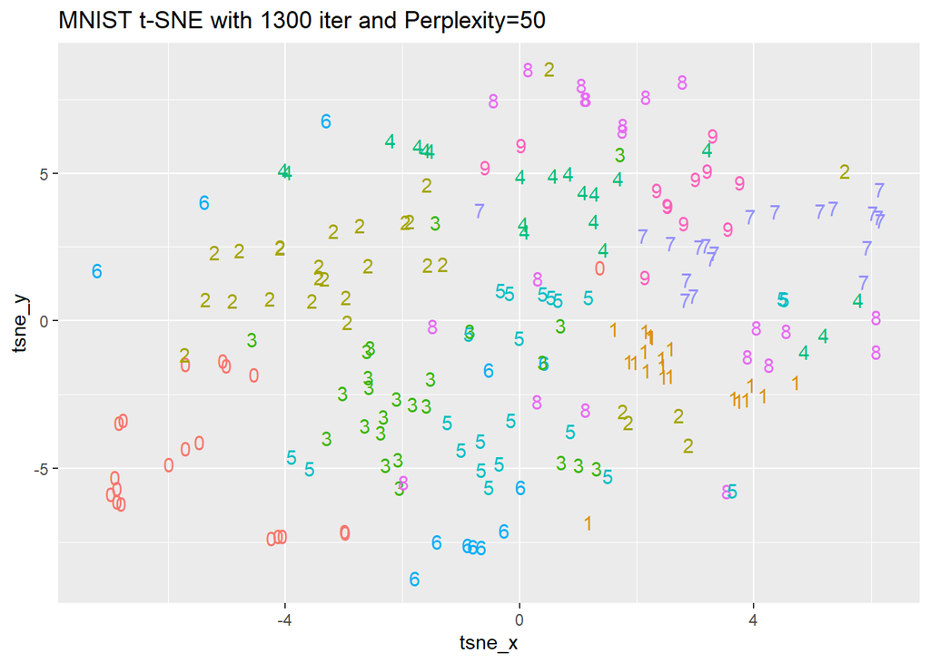

```r
ggplot(tsne_plot_50, aes(x = tsne_x, y = tsne_y, color = digit)) +
    ggtitle("MNIST t-SNE with 1300 iter and Perplexity=50") +
    geom_text(aes(label = digit)) +
    theme(legend.position="none")
```

## Plotting spatial distribution of true classes

As seen in the video, you can use the obtained representation of t-SNE in a lower dimension space to classify new digits based on the Euclidean distance to known clusters of digits. For this task, let’s start with plotting the spatial distribution of the digit labels in the embedding space. You are going to use the output of a t-SNE execution of 10K MNIST records named tsne and the true labels can be found in a dataset named mnist_10k. In this exercise, you will use the first 5K records of tsne and mnist_10k datasets and the goal is to visualize the obtained t-SNE embedding. The ggplot2 package has been loaded for you.

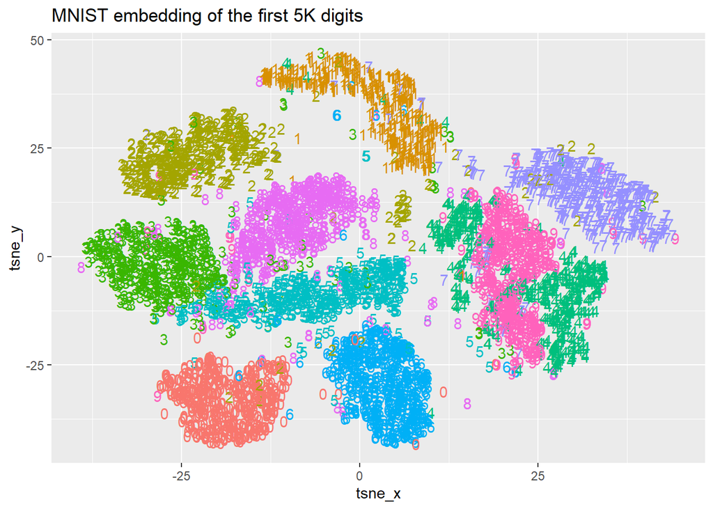

```r
library(data.table)
mnist_10k <- readRDS("mnist_10k.rds") %>% setDT()
tsne <- Rtsne(mnist_10k[, -1], perplexity = 50, max_iter = 1500)
# Prepare the data.frame
tsne_plot <- data.frame(tsne_x = tsne$Y[1:5000, 1],
                        tsne_y = tsne$Y[1:5000, 2],
                        digit = as.factor(mnist_10k[1:5000, ]$label))

# Plot the obtained embedding
ggplot(tsne_plot, aes(x = tsne_x, y = tsne_y, color = digit)) +
    ggtitle("MNIST embedding of the first 5K digits") +
    geom_text(aes(label = digit)) +
    theme(legend.position="none")
```

## Computing the centroids of each class

Since the previous visual representation of the digit in a low dimensional space makes sense, you want to compute the centroid of each class in this lower dimensional space. This centroid can be used as a prototype of the digit and you can classify new digits based on their Euclidean distance to these ones. The MNIST data mnist_10k and t-SNE output tsne are available in the workspace. The data.table package has been loaded for you.

```r
# Get the first 5K records and set the column names
dt_prototypes <- as.data.table(tsne$Y[1:5000,])
setnames(dt_prototypes, c("X","Y"))

# Paste the label column as factor
dt_prototypes[, label := as.factor(mnist_10k[1:5000,]$label)]

# Compute the centroids per label
dt_prototypes[, mean_X := mean(X), by = label]
dt_prototypes[, mean_Y := mean(Y), by = label]

# Get the unique records per label
dt_prototypes <- unique(dt_prototypes, by = "label")
dt_prototypes
```

| X | Y | label | mean_X | mean_Y |
| --- | --- | --- | --- | --- |
| 35.905392 | 16.980593 | 7 | 30.998559 | 13.900153 |
| 16.688802 | 3.686773 | 4 | 22.973958 | -5.162532 |
| 9.011413 | 24.546506 | 1 | 1.342618 | 34.936178 |
| 9.085808 | -27.024510 | 6 | 3.354923 | -28.237957 |
| -11.568422 | -6.258058 | 5 | -6.206452 | -8.719360 |
| -6.156797 | 7.933667 | 8 | -8.753761 | 6.772841 |
| -35.044337 | 2.062595 | 3 | -26.138387 | -1.341698 |
| -29.569892 | 17.242459 | 2 | -20.182239 | 21.649087 |
| -19.941166 | -31.414888 | 0 | -18.318613 | -32.757914 |
| 28.251837 | 3.109439 | 9 | 20.572886 | -3.998459 |

## Computing similarities of digits 1 and 0

One way to measure the label similarity for each digit is by computing the Euclidean distance in the lower dimensional space obtained from the t-SNE algorithm. You need to use the previously calculated centroids stored in dt_prototypes and compute the Euclidean distance to the centroid of digit 1 for the last 5000 records from tsne and mnist_10k datasets that are labeled either as 1 or 0. Note that the last 5000 records of tsne were not used before. The MNIST data mnist_10k and t-SNE output tsne are available in the workspace. The data.table package has been loaded for you.

```r
# Store the last 5000 records in distances and set column names
distances <- as.data.table(tsne$Y[5001:10000,])
setnames(distances, c("X", "Y"))
# Paste the true label
distances[, label := mnist_10k[5001:10000,]$label]
distances[, mean_X := mean(X), by = label]
distances[, mean_Y := mean(Y), by = label]


# Filter only those labels that are 1 or 0
distances_filtered <- distances[label == 1 | label == 0]

# Compute Euclidean distance to prototype of digit 1
distances_filtered[, dist_1 := sqrt( (X - dt_prototypes[label == 1,]$mean_X)^2 +
                             (Y - dt_prototypes[label == 1,]$mean_Y)^2)]
```

## Plotting similarities of digits 1 and 0

```r
# Compute the basic statistics of distances from records of class 1
summary(distances_filtered[label == 1]$dist_1)
```

```
##    Min. 1st Qu.  Median    Mean 3rd Qu.    Max.
##  0.4179  6.4020  9.3713  9.3682 12.1767 56.4937
```

```r
# Compute the basic statistics of distances from records of class 0
summary(distances_filtered[label == 0]$dist_1)
```

```
##    Min. 1st Qu.  Median    Mean 3rd Qu.    Max.
##   52.07   66.33   70.22   70.45   74.75   80.79
```

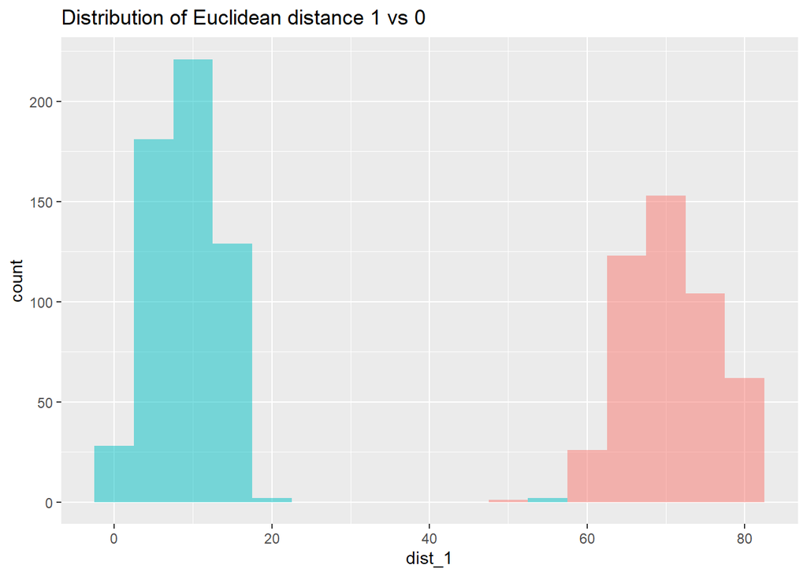

```r
# Plot the histogram of distances of each class
ggplot(distances_filtered,
       aes(x = dist_1, fill = as.factor(label))) +
    geom_histogram(binwidth = 5, alpha = .5,
                   position = "identity", show.legend = FALSE) +
    ggtitle("Distribution of Euclidean distance 1 vs 0")
```

## Exploring credit card fraud dataset

In this exercise, you will do some data exploration on a sample of the credit card fraud detection dataset from Kaggle. For any problem, starting with some data exploration is a good practice and helps us better understand the characteristics of the data.

The credit card fraud dataset is already loaded in the environment as a data table with the name creditcard. As you saw in the video, it consists of 30 numerical variables. The Class column indicates if the transaction is fraudulent. The ggplot2 package has been loaded for you.

```r
load("creditcard.RData")

setDT(creditcard)
# Look at the data dimensions
dim(creditcard)
```

```
## [1] 28923    31
```

```r
# Explore the column names
#names(creditcard)

# Explore the structure
#str(creditcard)

# Generate a summary
summary(creditcard)
```

```
##       Time              V1                  V2
##  Min.   :    26   Min.   :-56.40751   Min.   :-72.71573
##  1st Qu.: 54230   1st Qu.: -0.96058   1st Qu.: -0.58847
##  Median : 84512   Median : -0.02400   Median :  0.08293
##  Mean   : 94493   Mean   : -0.08501   Mean   :  0.05955
##  3rd Qu.:139052   3rd Qu.:  1.30262   3rd Qu.:  0.84003
##  Max.   :172788   Max.   :  2.41150   Max.   : 22.05773
##        V3                 V4                  V5
##  Min.   :-31.1037   Min.   :-5.071241   Min.   :-31.35675
##  1st Qu.: -0.9353   1st Qu.:-0.824978   1st Qu.: -0.70869
##  Median :  0.1659   Median : 0.007618   Median : -0.06071
##  Mean   : -0.1021   Mean   : 0.073391   Mean   : -0.04367
##  3rd Qu.:  1.0119   3rd Qu.: 0.789293   3rd Qu.:  0.61625
##  Max.   :  3.8771   Max.   :16.491217   Max.   : 34.80167
##        V6                  V7                  V8
##  Min.   :-26.16051   Min.   :-43.55724   Min.   :-50.42009
##  1st Qu.: -0.78792   1st Qu.: -0.57404   1st Qu.: -0.21025
##  Median : -0.28396   Median :  0.02951   Median :  0.01960
##  Mean   : -0.02722   Mean   : -0.08873   Mean   : -0.00589
##  3rd Qu.:  0.37911   3rd Qu.:  0.57364   3rd Qu.:  0.33457
##  Max.   : 20.37952   Max.   : 29.20587   Max.   : 20.00721
##        V9                 V10                 V11
##  Min.   :-13.43407   Min.   :-24.58826   Min.   :-4.11026
##  1st Qu.: -0.66974   1st Qu.: -0.54827   1st Qu.:-0.75404
##  Median : -0.06343   Median : -0.09843   Median :-0.01036
##  Mean   : -0.04295   Mean   : -0.08468   Mean   : 0.06093
##  3rd Qu.:  0.58734   3rd Qu.:  0.44762   3rd Qu.: 0.77394
##  Max.   :  8.95567   Max.   : 15.33174   Max.   :12.01891
##       V12                V13                 V14
##  Min.   :-18.6837   Min.   :-3.844974   Min.   :-19.21432
##  1st Qu.: -0.4365   1st Qu.:-0.661168   1st Qu.: -0.44507
##  Median :  0.1223   Median :-0.009685   Median :  0.04865
##  Mean   : -0.0943   Mean   :-0.002110   Mean   : -0.09653
##  3rd Qu.:  0.6172   3rd Qu.: 0.664794   3rd Qu.:  0.48765
##  Max.   :  4.8465   Max.   : 4.569009   Max.   :  7.75460
##       V15                 V16                 V17
##  Min.   :-4.498945   Min.   :-14.12985   Min.   :-25.1628
##  1st Qu.:-0.595272   1st Qu.: -0.48770   1st Qu.: -0.4951
##  Median : 0.045992   Median :  0.05736   Median : -0.0742
##  Mean   :-0.007251   Mean   : -0.06186   Mean   : -0.1046
```

[output cut: 22 more lines]

```
##  Max.   : 3.962197   Max.   : 5.376595   Max.   : 3.119295
##       V27                 V28               Amount
##  Min.   :-8.358317   Min.   :-8.46461   Min.   :    0.00
##  1st Qu.:-0.071275   1st Qu.:-0.05424   1st Qu.:    5.49
##  Median : 0.002727   Median : 0.01148   Median :   22.19
##  Mean   :-0.000501   Mean   : 0.00087   Mean   :   87.90
##  3rd Qu.: 0.095974   3rd Qu.: 0.08238   3rd Qu.:   78.73
##  Max.   : 7.994762   Max.   :33.84781   Max.   :11898.09
##     Class
##  Length:28923
##  Class :character
##  Mode  :character
##
##
##
```

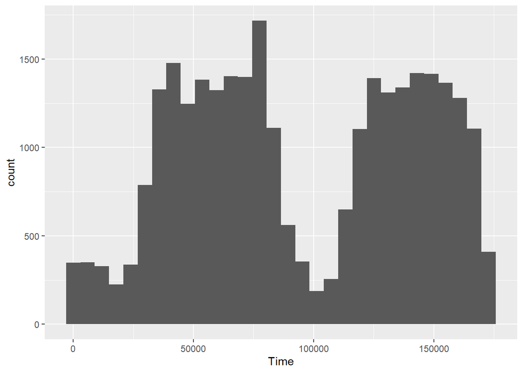

```r
# Plot a histogram of the transaction time
ggplot(creditcard, aes(x = Time)) +
    geom_histogram()
```

## Generating training and test sets

Before we can apply the t-SNE algorithm to perform a dimensionality reduction, we need to split the original data into a training and test set. Next, we will perform an under-sampling of the majority class and generate a balanced training set. Generating a balanced dataset is a good practice when we are using tree-based models. In this exercise you already have the creditcard dataset loaded in the environment. The ggplot2 and data.table packages are already loaded.

```r
# Extract positive and negative instances of fraud
creditcard_pos <- creditcard[Class == 1]
creditcard_neg <- creditcard[Class == 0]

# Fix the seed
set.seed(1234)

# Create a new negative balanced dataset by undersampling
creditcard_neg_bal <- creditcard_neg[sample(1:nrow(creditcard_neg), nrow(creditcard_pos))]

# Generate a balanced train set
creditcard_train <- rbind(creditcard_pos, creditcard_neg_bal)
```

## Training a random forest with original features

In this exercise, we are going to train a random forest model using the original features from the credit card dataset. The goal is to detect new fraud instances in the future and we are doing that by learning the patterns of fraud instances in the balanced training set. Remember that a random forest can be trained with the following piece of code: randomForest(x = features, y = label, ntree = 100) The only pre-processing that has been done to the original features was to scale the Time and Amount variables. You have the balanced training dataset available in the environment as creditcard_train. The randomForest package has been loaded.

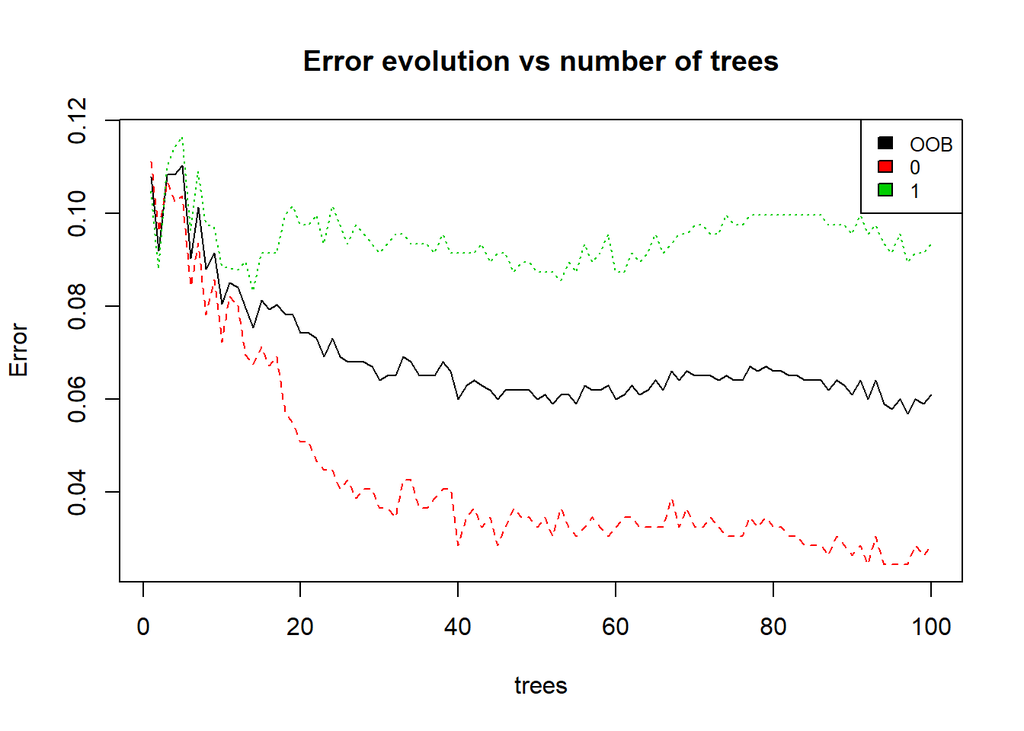

```r
# Fix the seed
set.seed(1234)
library(randomForest)
# Separate x and y sets
train_x <- creditcard_train[,-31]
train_y <- creditcard_train$Class %>% as.factor()

# Train a random forests
rf_model <- randomForest(x = train_x, y = train_y, ntree = 100)

# Plot the error evolution and variable importance
plot(rf_model, main = "Error evolution vs number of trees")
# Fix the seed
set.seed(1234)

# Separate x and y sets
train_x <- creditcard_train[,-31]
train_y <- creditcard_train$Class %>%as.factor()

# Train a random forests
rf_model <- randomForest(x = train_x, y = train_y, ntree = 100)

# Plot the error evolution and variable importance
plot(rf_model, main = "Error evolution vs number of trees")
legend("topright", colnames(rf_model$err.rate),col=1:3,cex=0.8,fill=1:3)
```

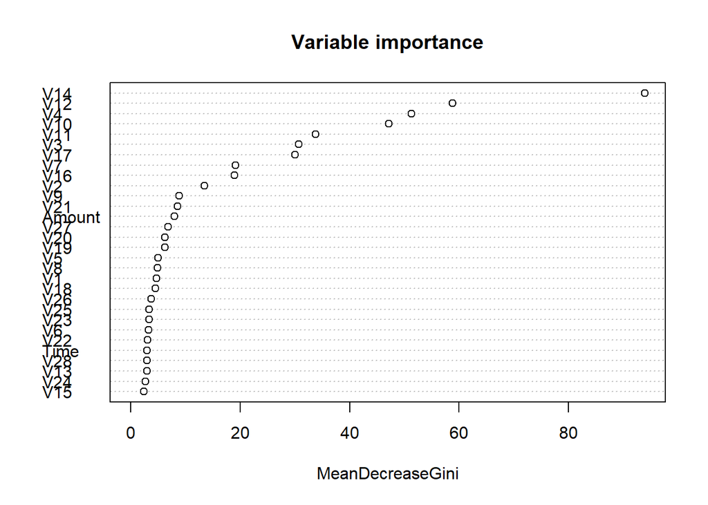

```r
varImpPlot(rf_model, main = "Variable importance")
```

## Computing and visualising the t-SNE embedding

In this exercise, we are going to generate a t-SNE embedding using only the balanced training set creditcard_train. The idea is to train a random forest using the two coordinates of the generated embedding instead of the original 30 dimensions. Due to computational restrictions, we are going to compute the embedding of the training data only, but note that in order to generate predictions from the test set we should compute the embedding of the test set together with the train set. Then, we will visualize the obtained embedding highlighting the two classes in order to clarify if we can differentiate between fraud and non-fraud transactions. The creditcard_train data, as well as the Rtsne and ggplot2 packages, have been loaded.

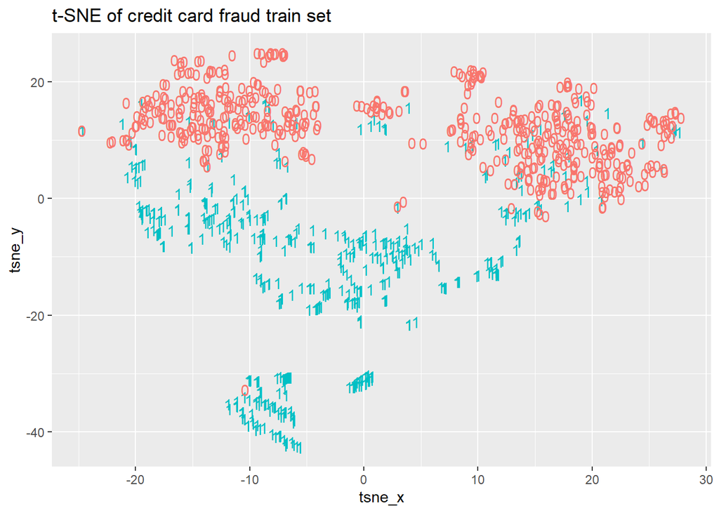

```r
# Set the seed
#set.seed(1234)

# Generate the t-SNE embedding
creditcard_train[, Time := scale(Time)]
nms <- names(creditcard_train)
pred_nms <- nms[nms != "Class"]
range01 <- function(x){(x-min(x))/(max(x)-min(x))}
creditcard_train[, (pred_nms) := lapply(.SD ,range01), .SDcols = pred_nms]

tsne_output <- Rtsne(as.matrix(creditcard_train[, -31]), check_duplicates = FALSE, PCA = FALSE)

# Generate a data frame to plot the result
tsne_plot <- data.frame(tsne_x = tsne_output$Y[,1],
                        tsne_y = tsne_output$Y[,2],
                        Class = creditcard_train$Class)

# Plot the embedding usign ggplot and the label
ggplot(tsne_plot, aes(x = tsne_x, y = tsne_y, color = factor(Class))) +
  ggtitle("t-SNE of credit card fraud train set") +
  geom_text(aes(label = Class)) + theme(legend.position = "none")
```

## Training a random forest with embedding features

In this exercise, we are going to train a random forest model using the embedding features from the previous t-SNE embedding. So, in this case, we are going to use a two-dimensional dataset that has been generated from the original input features. In the rest of the chapter, we are going to verify if we have a worse, similar, or better performance for this model in comparison to the random forest trained with the original features. In the environment two objects named train_tsne_x and train_tsne_y that contain the features and the Class variable are available. The randomForest package has been loaded as well.

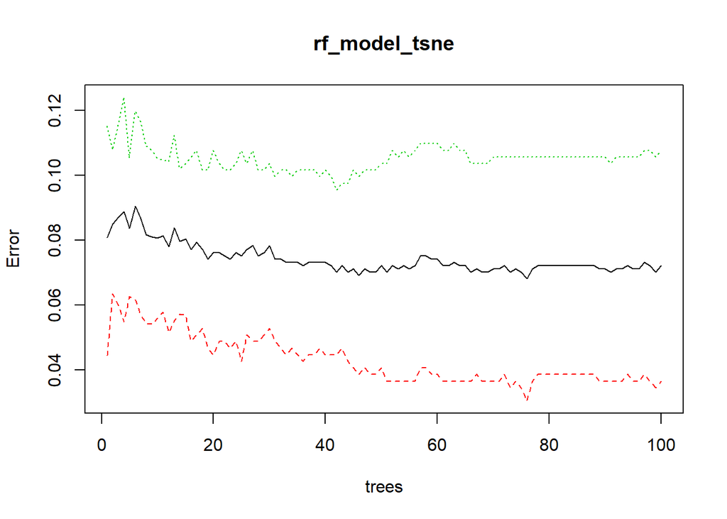

```r
# Fix the seed
set.seed(1234)
train_tsne_x <- tsne_output$Y
# Train a random forest
rf_model_tsne <- randomForest(x = train_tsne_x, y = train_y, ntree = 100)

# Plot the error evolution

plot(rf_model_tsne)
```

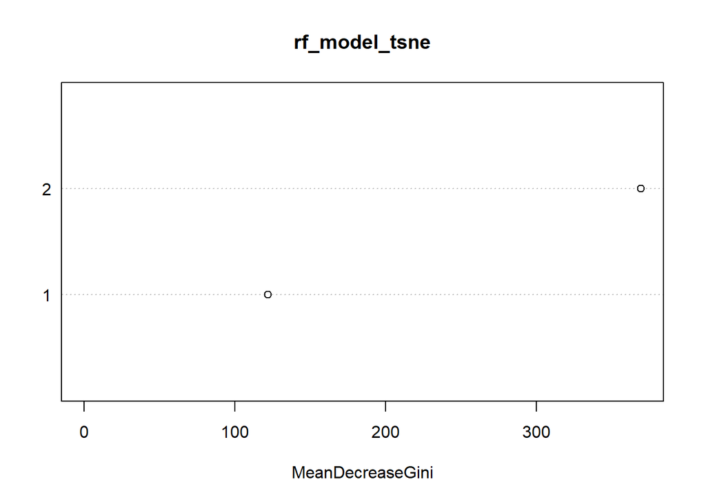

```r
# Plot the variable importance
varImpPlot(rf_model_tsne)
```

## Predicting data using original features

In this exercise, we are using the random forest trained with the original features and generate predictions using the test set. These predictions will be plotted to see the distribution and will be evaluated using the ROCR package by considering the area under the curve.

The random forest model, named rf_model, and the test set, named creditcard_test, are available in the environment. The randomForest and ROCR packages have been loaded for you

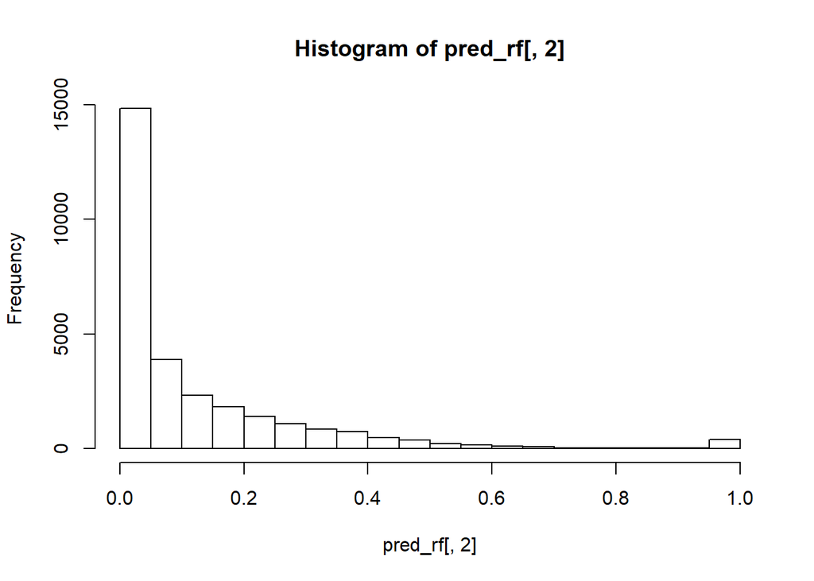

```r
# Predict on the test set using the random forest
creditcard_test <- creditcard
pred_rf <- predict(rf_model, creditcard_test, type = "prob")

# Plot a probability distibution of the target class
hist(pred_rf[,2])
```

```r
library(ROCR)
# Compute the area under the curve
pred <-  prediction(pred_rf[,2], creditcard_test$Class)
perf <- performance(pred, measure = "auc")
perf@y.values
```

```
## [[1]]
## [1] 0.9995958
```

## Predicting data using embedding random forest

Now, we are going to do the same analysis, but instead of using the random forest trained with the original features, we will make predictions using the random forest trained with the t-SNE embedding coordinates. The random forest model is pre-loaded in an object named rf_model_tsne and the t-SNE embedding features from the original test set are stored in the object test_x. Finally, the test set labels are stored in creditcard_test. The randomForest and ROCR packages have been loaded for you.

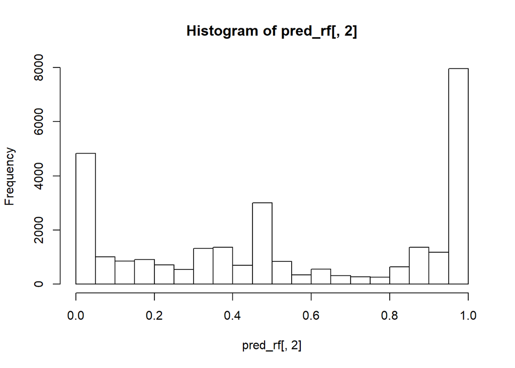

```r
creditcard_test[, (pred_nms) := lapply(.SD ,range01), .SDcols = pred_nms]

tsne_output <- Rtsne(as.matrix(creditcard_test[, -31]), check_duplicates = FALSE, PCA = FALSE)

test_x <- tsne_output$Y
# Predict on the test set using the random forest generated with t-SNE features
pred_rf <- predict(rf_model_tsne, test_x, type = "prob")

# Plot a probability distibution of the target class
hist(pred_rf[, 2])
```

```r
# Compute the area under the curve
pred <- prediction(pred_rf[, 2] , creditcard_test$Class)
perf <- performance(pred, measure = "auc")
perf@y.values
```

```
## [[1]]
## [1] 0.1952886
```

## Exploring neural network layer output

In this exercise, we will have a look at the data that is being generated in a specific layer of a neural network. In particular, this data corresponds to the third layer, composed of 128 neurons, of a neural network trained with the balanced credit card fraud dataset generated before. The goal of the exercise is to perform an exploratory data analysis.

```r
# Observe the dimensions
#dim(layer_128_train)

# Show the first six records of the last ten columns
#head(layer_128_train[, 119:128])

# Generate a summary of all columns
#summary(layer_128_train)
```

## Using t-SNE to visualise a neural network layer

Now, we would like to visualize the patterns obtained from the neural network model, in particular from the last layer of the neural network. As we mentioned before this last layer has 128 neurons and we have pre-loaded the weights of these neurons in an object named layer_128_train. The goal is to compute a t-SNE embedding using the output of the neurons from this last layer and visualize the embedding colored according to the class. The Rtsne and ggplot2 packages as well as the layer_128_train and creditcard_train have been loaded for you

```r
# Set the seed
set.seed(1234)

# Generate the t-SNE
#tsne_output <- Rtsne(as.matrix(layer_128_train), check_duplicates = FALSE, max_iter = 400, perplexity = 50)

# Prepare data.frame
#tsne_plot <- data.frame(tsne_x = tsne_output$Y[, 1], tsne_y = tsne_output$Y[, 2],
#                        Class = creditcard_train$Class)

# Plot the data
# ggplot(tsne_plot, aes(x = tsne_x, y = tsne_y, color = Class)) +
#   geom_point() +
#   ggtitle("Credit card embedding of Last Neural Network Layer")
```

## Using t-SNE to visualise a neural network layer

Now, we would like to visualize the patterns obtained from the neural network model, in particular from the last layer of the neural network. As we mentioned before this last layer has 128 neurons and we have pre-loaded the weights of these neurons in an object named layer_128_train. The goal is to compute a t-SNE embedding using the output of the neurons from this last layer and visualize the embedding colored according to the class. The Rtsne and ggplot2 packages as well as the layer_128_train and creditcard_train have been loaded for you

```r
# Set the seed
# set.seed(1234)
#
# # Generate the t-SNE
# tsne_output <- Rtsne(as.matrix(layer_128_train), check_duplicates = FALSE, max_iter = 400, perplexity = 50)
#
# # Prepare data.frame
# tsne_plot <- data.frame(tsne_x = tsne_output$Y[, 1], tsne_y = tsne_output$Y[, 2],
#                         Class = creditcard_train$Class)
#
# # Plot the data
# ggplot(tsne_plot, aes(x = tsne_x, y = tsne_y, color = Class)) +
#   geom_point() +
#   ggtitle("Credit card embedding of Last Neural Network Layer")
```

## Exploring fashion MNIST

```r
library(data.table)
#load("fashion_mnist_500.RData")
fashion_mnist <- fread(unzip("fashionmnist.zip", "fashion-mnist_train.csv"))
set.seed(100)

ind <- sample(1:nrow(fashion_mnist), 1000)

fashion_mnist <- fashion_mnist[ind, ]
# Show the dimensions
dim(fashion_mnist)
```

```
## [1] 1000  785
```

```r
# Create a summary of the last six columns
summary(fashion_mnist[, 780:785])
```

```
##     pixel779         pixel780         pixel781        pixel782
##  Min.   :  0.00   Min.   :  0.00   Min.   :  0.0   Min.   :  0.000
##  1st Qu.:  0.00   1st Qu.:  0.00   1st Qu.:  0.0   1st Qu.:  0.000
##  Median :  0.00   Median :  0.00   Median :  0.0   Median :  0.000
##  Mean   : 22.16   Mean   : 18.64   Mean   : 10.6   Mean   :  3.781
##  3rd Qu.:  1.00   3rd Qu.:  0.00   3rd Qu.:  0.0   3rd Qu.:  0.000
##  Max.   :236.00   Max.   :255.00   Max.   :231.0   Max.   :188.000
##     pixel783          pixel784
##  Min.   :  0.000   Min.   : 0.000
##  1st Qu.:  0.000   1st Qu.: 0.000
##  Median :  0.000   Median : 0.000
##  Mean   :  0.934   Mean   : 0.043
##  3rd Qu.:  0.000   3rd Qu.: 0.000
##  Max.   :147.000   Max.   :39.000
```

```r
# Table with the class distribution
table(fashion_mnist$label)
```

```
##
##   0   1   2   3   4   5   6   7   8   9
## 100  94 115  90  97  98  97 105 102 102
```

## Visualizing fashion MNIST

In this exercise, we are going to visualize an example image of the fashion MNIST dataset. Basically, we are going to plot the 28x28 pixels values. To do this we use:

```r
library(tidyverse)
plot_theme <- list(
    raster = geom_raster(hjust = 0, vjust = 0),
    gradient_fill = scale_fill_gradient(low = "white",
                                        high = "black", guide = FALSE),
    theme = theme(axis.line = element_blank(),
                  axis.text = element_blank(),
                  axis.ticks = element_blank(),
                  axis.title = element_blank(),
                  panel.background = element_blank(),
                  panel.border = element_blank(),
                  panel.grid.major = element_blank(),
                  panel.grid.minor = element_blank(),
                  plot.background = element_blank()))
```

```r
class_names <-  c("T-shirt/top", "Trouser", "Pullover",
                  "Dress", "Coat", "Sandal", "Shirt",
                  "Sneaker", "Bag", "Ankle", "boot")


xy_axis <- data.frame(x = expand.grid(1:28, 28:1)[,1],
                      y = expand.grid(1:28, 28:1)[,2])

# Get the data from the last image
plot_data <- cbind(xy_axis, fill = as.data.frame(t(fashion_mnist[500, -1]))[,1])

# Observe the first records
head(plot_data)
```

|  | x | y | fill |
| --- | --- | --- | --- |
| 1 | 1 | 28 | 0 |
| 2 | 2 | 28 | 0 |
| 3 | 3 | 28 | 0 |
| 4 | 4 | 28 | 0 |
| 5 | 5 | 28 | 0 |
| 6 | 6 | 28 | 0 |

[figure not shown]

```r
# Plot the image using ggplot()
ggplot(plot_data, aes(x, y, fill = fill)) +
  ggtitle(class_names[as.integer(fashion_mnist[500, 1])]) +
  plot_theme
```

## Reducing data with GLRM

We are going to reduce the dimensionality of the fashion MNIST sample data using the GLRM implementation of h2o. In order to do this, in the next steps we are going to: Start a connection to a h2o cluster by invoking the method h2o.init(). Store the fashion_mnist data into the h2o cluster with as.h2o(). Launch a GLRM model with K=2 (rank-2 model) using the h2o.glrm() function. As we have discussed in the video session, it is important to check the convergence of the objective function. Note that here we are also fixing the seed to ensure the same results. The h2o package and fashion_mnist data are pre-loaded in the environment.

```r
library(h2o)
# Start a connection with the h2o cluster
h2o.init()
```

[output not shown]

```r
# Store the data into h2o cluster
fashion_mnist.hex <- as.h2o(fashion_mnist, "fashion_mnist.hex")
# Launch a GLRM model over fashion_mnist data
model_glrm <- h2o.glrm(training_frame = fashion_mnist.hex,
                       cols = 2:ncol(fashion_mnist),
                       k = 2,
                       seed = 123,
                       max_iterations = 2100)
```

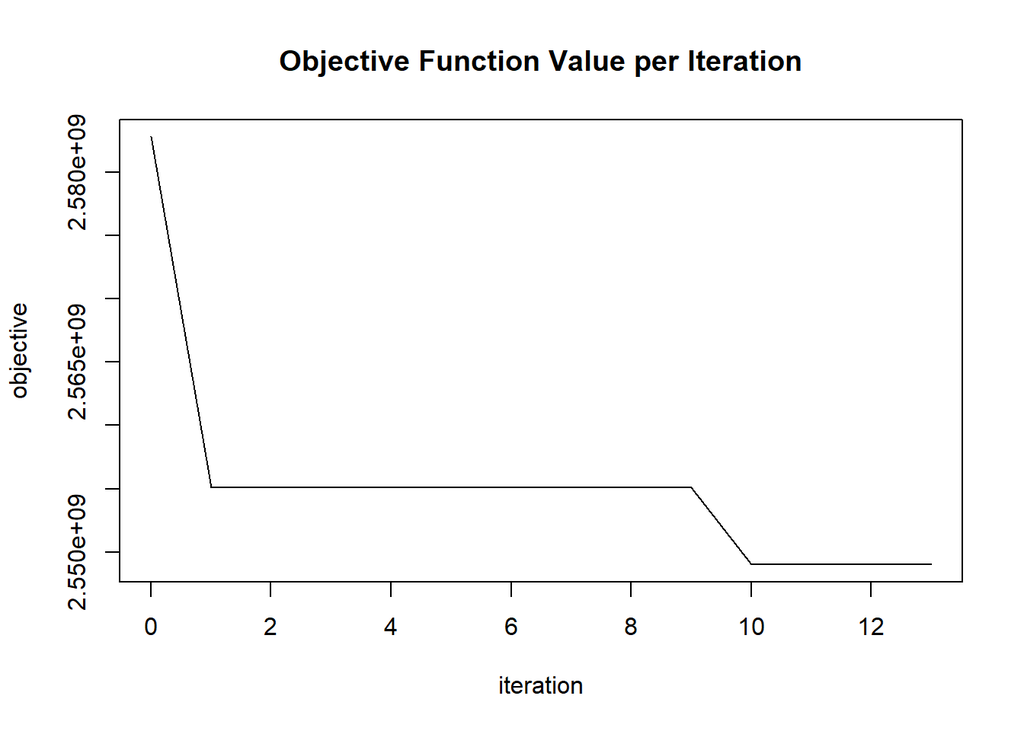

```r
# Plotting the convergence
plot(model_glrm)
```

## Improving model convergence

In the previous exercise, we didn’t get good convergence values for the GLRM model. Improving convergence values can sometimes be achieved by applying a transformation to the input data. In this exercise, we are going to normalize the input data before we start building the GLRM model. This can be achieved by setting the transform parameter of h2o.glrm() equal to “NORMALIZE”. The h2o package and fashion_mnist dataset are pre-loaded.

```r
# Start a connection with the h2o cluster
#h2o.init()

# Store the data into h2o cluster
#fashion_mnist.hex <- as.h2o(fashion_mnist, "fashion_mnist.hex")

# Launch a GLRM model with normalized fashion_mnist data
model_glrm <- h2o.glrm(training_frame = fashion_mnist.hex,
                       transform = "NORMALIZE",
                       cols = 2:ncol(fashion_mnist),
                       k = 2,
                       seed = 123,
                       max_iterations = 2100)
```

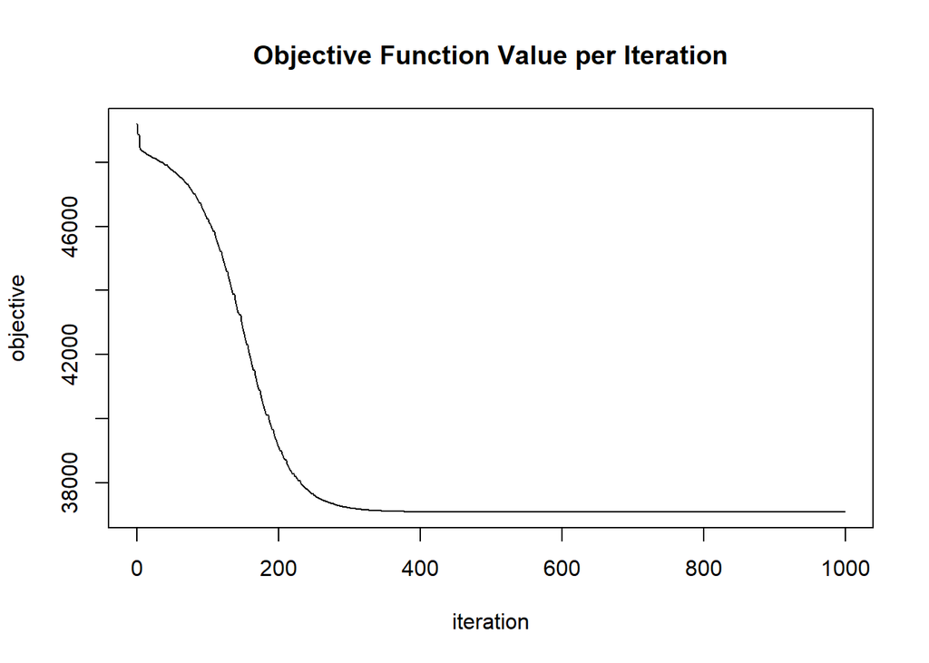

```r
# Plotting the convergence
plot(model_glrm)
```

## Visualizing the output of GLRM

A GLRM model generates the X and Y matrixes. In this exercise, we are going to visualize the obtained low-dimensional representation of the input records in the new K-dimensional space. The output of the X matrix from the previous GLRM model has been loaded with the name X_matrix. This matrix has been obtained by calling:

```r
X_matrix <- as.data.table(h2o.getFrame(model_glrm@model$representation_name))
# Dimension of X_matrix
dim(X_matrix)
```

```
## [1] 1000    2
```

```r
# First records of X_matrix
head(X_matrix)
```

| Arch1 | Arch2 |
| --- | --- |
| -1.4562898 | 0.28620951 |
| 0.7132191 | 1.18922464 |
| 0.5600450 | -1.29628758 |
| 0.9997013 | -0.51894405 |
| 1.3377989 | -0.05616662 |
| 1.0687898 | 0.07447071 |

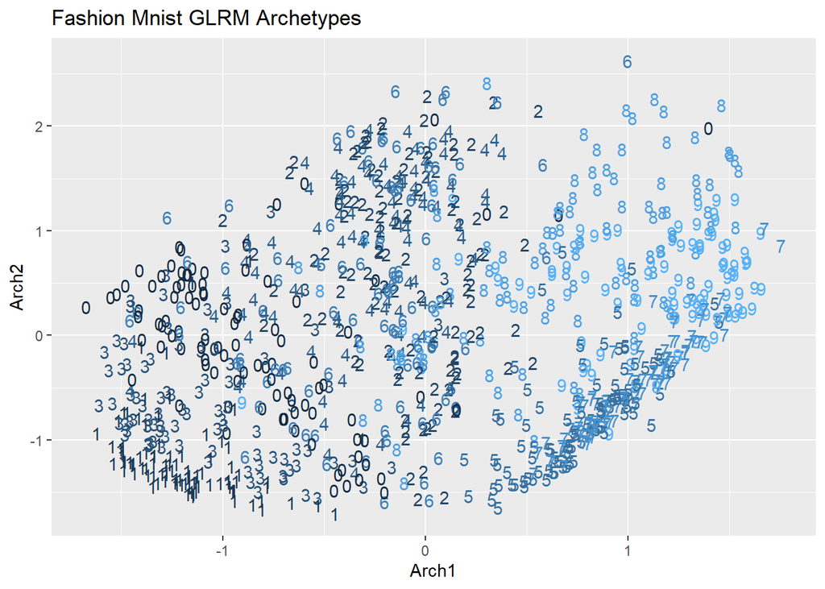

```r
# Plot the records in the new two dimensional space
ggplot(as.data.table(X_matrix), aes(x= Arch1, y = Arch2, color =  fashion_mnist$label)) +
    ggtitle("Fashion Mnist GLRM Archetypes") +
    geom_text(aes(label =  fashion_mnist$label)) +
    theme(legend.position="none")
```

## Visualizing the prototypes

Now, we are going to compute the centroids of the coordinates for each of the two archetypes for each label. We did something similar before for the t-SNE embedding. The goal is to have a representation or prototype of each label in this new two-dimensional space.

The ggplot2 and data.table packages are pre-loaded, as well as the X_matrix object and the fashion_mnist dataset.

[figure not shown]

```r
# Store the label of each record and compute the centroids
X_matrix[, label := as.numeric(fashion_mnist$label)]
X_matrix[, mean_x := mean(Arch1), by = label]
X_matrix[, mean_y := mean(Arch2), by = label]

# Get one record per label and create a vector with class names
X_mean <- unique(X_matrix, by = "label")

label_names <- c("T-shirt/top", "Trouser", "Pullover",
                 "Dress", "Coat", "Sandal", "Shirt",
                 "Sneaker", "Bag", "Ankle boot")

# Plot the centroids
X_mean[, label := factor(label, levels = 0:9, labels = label_names)]
ggplot(X_mean, aes(x = mean_x, y = mean_y, color = label_names)) +
    ggtitle("Fashion Mnist GLRM class centroids") +
    geom_text(aes(label = label_names)) +
    theme(legend.position = "none")
```

## Imputing missing data

In this exercise, we will use GLRM to impute missing data. We are going to build a GLRM model from a dataset named fashion_mnist_miss, where 20% of values are missing. The goal is to fill these values by making a prediction using h2o.predict() with the GLRM model. In this exercise an h2o instance is already running, so it is not necessary to call h2o.init(). The h2o package and fashion_mnist_miss have been loaded

```r
fashion_mnist_miss <- h2o.insertMissingValues(fashion_mnist.hex,
                                              fraction = 0.2, seed = 1234)
# Store the input data in h2o
fashion_mnist_miss.hex <- as.h2o(fashion_mnist_miss, "fashion_mnist_miss.hex")

# Build a GLRM model
model_glrm <- h2o.glrm(training_frame = fashion_mnist_miss.hex,
                       k = 2,
                       transform = "NORMALIZE",
                       max_iterations = 100)
# Impute missing values
fashion_pred <- predict(model_glrm, fashion_mnist_miss.hex)
# Observe the statistics of the first 5 pixels
summary(fashion_pred[, 1:5])
```

```
##  reconstr_label     reconstr_pixel2      reconstr_pixel3
##  Min.   :-0.47950   Min.   :-0.0015568   Min.   :-0.0048536
##  1st Qu.:-0.26059   1st Qu.:-0.0008525   1st Qu.:-0.0022268
##  Median :-0.07530   Median :-0.0002846   Median :-0.0003030
##  Mean   :-0.06522   Mean   :-0.0002330   Mean   :-0.0001716
##  3rd Qu.: 0.12724   3rd Qu.: 0.0003203   3rd Qu.: 0.0018569
##  Max.   : 0.39351   Max.   : 0.0018132   Max.   : 0.0058790
##  reconstr_pixel4      reconstr_pixel5
##  Min.   :-0.0060428   Min.   :-0.0035266
##  1st Qu.:-0.0030836   1st Qu.:-0.0019180
##  Median :-0.0011572   Median : 0.0003117
##  Mean   :-0.0009483   Mean   : 0.0001418
##  3rd Qu.: 0.0012697   3rd Qu.: 0.0019282
##  Max.   : 0.0066305   Max.   : 0.0044367
```

##Training a random forest with original data

```r
# Get the starting timestamp
library(randomForest)

time_start <- proc.time()

# Train the random forest
fashion_mnist[, label := factor(label)]
rf_model <- randomForest(label~., ntree = 20,
                         data = fashion_mnist)

# Get the end timestamp
time_end <- timetaken(time_start)

# Show the error and the time
rf_model$err.rate[20]
```

```
## [1] 0.2512513
```

```r
time_end
```

```
## [1] "1.160s elapsed (1.160s cpu)"
```

## Training a random forest with compressed data

In this exercise, you a dataset named train_x that contains the compressed training data and another one named train_y that contains the labels are pre-loaded. We are going to calculate computation time and accuracy, similar to what was done in the previous exercise. Since the dimensionality of this dataset is much smaller, we can train a random forest using 500 trees in less time. The randomForest package is already loaded.

```r
model_glrm <- h2o.glrm(training_frame = fashion_mnist.hex,
                       transform = "NORMALIZE",
                       cols = 2:ncol(fashion_mnist),
                       k = 8,
                       seed = 123,
                       max_iterations = 1000)
train_x <- as.data.table(h2o.getFrame(model_glrm@model$representation_name))
train_y <- fashion_mnist$label %>% as.factor()
```

```r
library(randomForest)
# Get the starting timestamp
time_start <- proc.time()

# Train the random forest
rf_model <- randomForest(x = train_x, y = train_y, ntree = 500)

# Get the end timestamp
time_end <- timetaken(time_start)


# Show the error and the time
rf_model$err.rate[500]
```

```
## [1] 0.259
```

```r
time_end
```

```
## [1] "0.390s elapsed (0.390s cpu)"
```